# Spatial data handling

## Spatial data handling in R

Packages:

- `sp` First major spatial data package/format
- `rgdal` reading and writing spatial data
- `rgeos` Interface to open-source geometry engine (GEOS)
- `sf` Spatial Features in the ‘tidyverse’
- `raster` raster (gridded) data
- and a few others…

## What is a Spatial Feature (sf)?

Typically an object in the real world, such as a building or a tree.

A forest stand can be a feature, a forest can be a feature, a city can be a feature. A satellite image pixel can be a feature, a complete image can be a feature too.

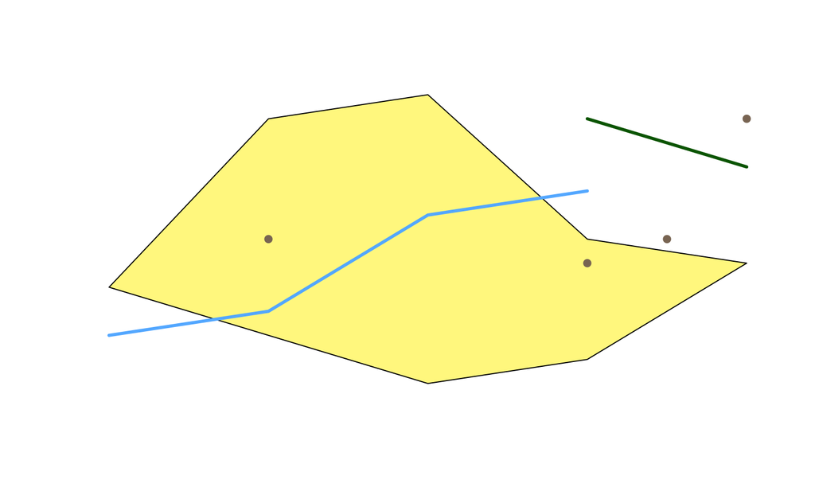

## Spatial Features

What information do we need to store in order to define points, lines, polygons in geographic space?

- lat/lon coordinates
- projection
- what type (point/line/poly)
- if polygon, is it a hole or not
- attribute data
- … ?

## Geometry

Features have a *geometry* describing *where* on Earth the feature is located, and they have attributes, which describe other properties.

A Tree:

- delineation of its crown
- its stem
- point indicating its centre

Attributes:

- species,
- height
- diameter at breast height at a particular date, and so on.

## Dimensions

All geometries composed of points. Points are coordinates in a 2-, 3- or 4-dimensional space. All points in a geometry have the same dimensionality. In addition to X and Y coordinates, there are two optional additional dimensions:

- a Z coordinate, denoting altitude
- an M coordinate (rarely used), denoting some *measure* that is associated with the point, rather than with the feature as a whole (in which case it would be a feature attribute); examples could be time of measurement, or measurement error of the coordinates

## Simple feature geometry types

The following seven simple feature types are the most common, and are for instance the only ones used for [GeoJSON](https://tools.ietf.org/html/rfc7946):

| type | description |
| --- | --- |
| `POINT` | a single point |
| `LINESTRING` | sequence of points connected by lines |
| `POLYGON` | sequence of points form a closed ring |
| `MULTIPOINT` | set of points |
| `MULTILINESTRING` | set of linestrings |
| `MULTIPOLYGON` | set of polygons |
| `GEOMETRYCOLLECTION` | set of geometries |

## Uncommon Geometry Types

10 more geometries 10 are rare:

- `CIRCULARSTRING`
- `COMPOUNDCURVE`
- `CURVEPOLYGON`
- `MULTICURVE`
- `MULTISURFACE`
- `CURVE`
- `SURFACE`
- `POLYHEDRALSURFACE`
- `TIN`
- `TRIANGLE`

## How simple features in R are organized

Package `sf` represents simple features as native R objects. Similar to [PostGIS](http://postgis.net/), all functions and methods in `sf` that operate on spatial data are prefixed by `st_`, which refers to *spatial and temporal*; this makes them easily findable by command-line completion. Simple features are implemented as R native data, using simple data structures (S3 classes, lists, matrix, vector). Typical use involves reading, manipulating and writing of sets of features, with attributes and geometries.

There are currently two main approaches in R to handle geographic vector data.

## `sp` package

First package to provide classes and methods for spatial data types in R is called [`sp`](https://cran.r-project.org/package=sp). Provides classes and methods to create *points*, *lines*, *polygons*, and *grids* and to operate on them.

About 350 of the spatial analysis packages use the spatial data types that are implemented in `sp` i.e. they “depend” on the `sp` package and many more are indirectly dependent.

Many spatial R packages still depends on the **sp** package, therefore it is important to know how to convert **sp** to and from **sf** objects

Foundational structure for any spatial object in `sp` is the `Spatial` class. It has two “slots” ([new-style S4 class objects in R have pre-defined components called slots](http://stackoverflow.com/a/4714080)):

- a **bounding box**
- a **CRS class object** to define the Coordinate Reference System

Basic structure extended depending on the characteristics of the spatial object (point, line, polygon).

## I. Create geometric objects (topology)

- **Points** most basic spatial data objects. Typically from a two-column matrix/dataframe with a column for latitude and one for longitude.
- **Lines** are generated out of `Line` objects. A `Line` object is a collection of 2D coordinates and is generated out of a two-column matrix or a dataframe with a column for latitude and one for longitude. A `Lines` object is a **list** of one or more `Line` objects.
- **Polygons** are generated out of `Polygon` objects. A `Polygon` object is a collection of 2D coordinates with equal first and last coordinates and is generated out of a two-column matrix or a dataframe with a column for latitude and one for longitude. A `Polygons` object is a **list** of one or more `Polygon` objects, for example islands belonging to the same country.

A very simple `Line` object:

```r
ln <- Line(matrix(runif(6), ncol=2))
str(ln)
```

```
## Formal class 'Line' [package "sp"] with 1 slot
##   ..@ coords: num [1:3, 1:2] 0.0739 0.5948 0.6837 0.7846 0.3823 ...
```

```r
ln@coords
```

```
##            [,1]      [,2]
## [1,] 0.07392059 0.7846486
## [2,] 0.59476176 0.3822716
## [3,] 0.68366794 0.8103448
```

A very simple `Lines` object:

```r
lns <- Lines(list(ln,ln), ID = "a") # this contains just two (identical) Lines!
str(lns)
```

```
## Formal class 'Lines' [package "sp"] with 2 slots
##   ..@ Lines:List of 2
##   .. ..$ :Formal class 'Line' [package "sp"] with 1 slot
##   .. .. .. ..@ coords: num [1:3, 1:2] 0.0739 0.5948 0.6837 0.7846 0.3823 ...
##   .. ..$ :Formal class 'Line' [package "sp"] with 1 slot
##   .. .. .. ..@ coords: num [1:3, 1:2] 0.0739 0.5948 0.6837 0.7846 0.3823 ...
##   ..@ ID   : chr "a"
```

## II. Create spatial objects `Spatial*` object (`*` stands for Points, Lines, or Polygons).

Adds bounding box and the slot for the Coordinate Reference System or CRS. `SpatialPoints` can be directly generated out of the coordinates. `SpatialLines` and `SpatialPolygons` objects are generated using lists of `Lines` or `Polygons` objects respectively (more below).

See here for how to create a `SpatialLines` object:

```r
sp_lns <- SpatialLines(list(lns))
str(sp_lns)
```

```
## Formal class 'SpatialLines' [package "sp"] with 3 slots
##   ..@ lines      :List of 1
##   .. ..$ :Formal class 'Lines' [package "sp"] with 2 slots
##   .. .. .. ..@ Lines:List of 2
##   .. .. .. .. ..$ :Formal class 'Line' [package "sp"] with 1 slot
##   .. .. .. .. .. .. ..@ coords: num [1:3, 1:2] 0.0739 0.5948 0.6837 0.7846 0.3823 ...
##   .. .. .. .. ..$ :Formal class 'Line' [package "sp"] with 1 slot
##   .. .. .. .. .. .. ..@ coords: num [1:3, 1:2] 0.0739 0.5948 0.6837 0.7846 0.3823 ...
##   .. .. .. ..@ ID   : chr "a"
##   ..@ bbox       : num [1:2, 1:2] 0.0739 0.3823 0.6837 0.8103
##   .. ..- attr(*, "dimnames")=List of 2
##   .. .. ..$ : chr [1:2] "x" "y"
##   .. .. ..$ : chr [1:2] "min" "max"
##   ..@ proj4string:Formal class 'CRS' [package "sp"] with 1 slot
##   .. .. ..@ projargs: chr NA
```

## III. Add attributes (*Optional*:)

Add attribute data, which will turn your `Spatial*` object into a `Spatial*DataFrame` object. ID fields are here required to match the data frame row names.

Create a simple `SpatialLinesDataframe`:

```r
dfr <- data.frame(id = "a", use = "road", cars_per_hour = 10) # note how we use the ID from above!
sp_lns_dfr <- SpatialLinesDataFrame(sp_lns, dfr, match.ID = "id")
str(sp_lns_dfr)
```

```
## Formal class 'SpatialLinesDataFrame' [package "sp"] with 4 slots
##   ..@ data       :'data.frame':  1 obs. of  3 variables:
##   .. ..$ id           : Factor w/ 1 level "a": 1
##   .. ..$ use          : Factor w/ 1 level "road": 1
##   .. ..$ cars_per_hour: num 10
##   ..@ lines      :List of 1
##   .. ..$ :Formal class 'Lines' [package "sp"] with 2 slots
##   .. .. .. ..@ Lines:List of 2
##   .. .. .. .. ..$ :Formal class 'Line' [package "sp"] with 1 slot
##   .. .. .. .. .. .. ..@ coords: num [1:3, 1:2] 0.0739 0.5948 0.6837 0.7846 0.3823 ...
##   .. .. .. .. ..$ :Formal class 'Line' [package "sp"] with 1 slot
##   .. .. .. .. .. .. ..@ coords: num [1:3, 1:2] 0.0739 0.5948 0.6837 0.7846 0.3823 ...
##   .. .. .. ..@ ID   : chr "a"
##   ..@ bbox       : num [1:2, 1:2] 0.0739 0.3823 0.6837 0.8103
##   .. ..- attr(*, "dimnames")=List of 2
##   .. .. ..$ : chr [1:2] "x" "y"
##   .. .. ..$ : chr [1:2] "min" "max"
##   ..@ proj4string:Formal class 'CRS' [package "sp"] with 1 slot
##   .. .. ..@ projargs: chr NA
```

## Commonly used spatial methods

| function | and what it does |
| --- | --- |
| `bbox()` | returns the bounding box coordinates |
| `proj4string()` | sets or retrieves projection attributes using the CRS object. |
| `CRS()` | creates an object of class of coordinate reference system arguments |
| `spplot()` | plots all the attributes |
| `coordinates()` | set or retrieve the spatial coordinates. |
| `over(a, b)` | used to retrieve the polygon or grid indices on a set of points |
| `spsample()` | sampling of spatial points within the spatial extent of objects |

## `sf` package

[`sf`](https://cran.r-project.org/package=sf) implements a formal standard called [“Simple Features”](https://en.wikipedia.org/wiki/Simple_Features) that specifies a storage and access model of spatial geometries (point, line, polygon). A feature geometry is called simple when it consists of points connected by straight line pieces, and does not intersect itself.

This standard has been adopted widely, not only by spatial databases such as PostGIS, but also more recent standards such as GeoJSON.

If you work with PostGis or GeoJSON you may have come across the [WKT (well-known text)](https://en.wikipedia.org/wiki/Well-known_text) format, for example like these:

```
`POINT (30 10)
LINESTRING (30 10, 10 30, 40 40)
POLYGON ((30 10, 40 40, 20 40, 10 20, 30 10))`
```

`sf` implements this standard natively in R. Data are structured and conceptualized very differently from the `sp` approach.

In `sf` spatial objects are stored as a simple data frame with a special column that contains the information for the geographic coordinates. That special column is a list with the same length as the number of rows in the data frame. Each of the individual list elements then can be of any length needed to hold the coordinates that correspond to an individual feature.

## I. Create geometric objects (topology)

Geometric objects (simple features) can be created from a numeric vector, matrix or a list with the coordinates. They are called `sfg` objects for Simple Feature Geometry.

See here for an example of how a LINESTRING `sfg` object is created:

```r
lnstr_sfg <- st_linestring(matrix(runif(6), ncol=2))
class(lnstr_sfg)
```

```
## [1] "XY"         "LINESTRING" "sfg"
```

## II. Combine all individual single feature objects for the special column.

In order to work our way towards a data frame for all features we create what is called an `sfc` object with all individual features, which stands for Simple Feature Collection. The `sfc` object also holds the bounding box and the projection information.

See here for an example of how a `sfc` object is created:

```r
(lnstr_sfc <- st_sfc(lnstr_sfg)) # just one feature here
```

```
## Geometry set for 1 feature
## geometry type:  LINESTRING
## dimension:      XY
## bbox:           xmin: 0.5792671 ymin: 0.2868948 xmax: 0.8412601 ymax: 0.6830851
## epsg (SRID):    NA
## proj4string:    NA
```

```
## LINESTRING (0.841260074405 0.683085091179237, 0...
```

```r
class(lnstr_sfc)
```

```
## [1] "sfc_LINESTRING" "sfc"
```

## III. Add attributes.

We now combine the dataframe with the attributes and the simple feature collection. See here how its done.

```r
(lnstr_sf <- st_sf(dfr , lnstr_sfc))
```

```
## Simple feature collection with 1 feature and 3 fields
## geometry type:  LINESTRING
## dimension:      XY
## bbox:           xmin: 0.5792671 ymin: 0.2868948 xmax: 0.8412601 ymax: 0.6830851
## epsg (SRID):    NA
## proj4string:    NA
##   id  use cars_per_hour                      lnstr_sfc
## 1  a road            10 LINESTRING (0.841260074405 ...
```

```r
class(lnstr_sf)
```

```
## [1] "sf"         "data.frame"
```

## sf Highlights

- provides **fast** I/O, particularly relevant for large files
- directly reads from and writes to spatial **databases** such as PostGIS
- compatibile with the *tidyverse*
- stay tuned for a new `ggplot` release that will be able to read and plot the `sf` format without the need of conversion to a data frame, like the `sp` format

`sp` and `sf` are *not* only formats for spatial objects. Other spatial packages may use their own class definitions for spatial data (for example `spatstat`). Usuallly you can find functions that convert `sp` and increasingly `sf` objects to and from these formats.

```r
world_sp = as(world, "Spatial")
world_sf = st_as_sf(world_sp)
str(world_sp)
```

[output not shown]

[output cut: 1556 more lines]

```
##   .. .. .. .. .. .. ..@ hole   : logi FALSE
##   .. .. .. .. .. .. ..@ ringDir: int 1
##   .. .. .. .. .. .. ..@ coords : num [1:22, 1:2] 21.1 21.1 21.6 22.5 23.3 ...
##   .. .. .. ..@ plotOrder: int 1
##   .. .. .. ..@ labpt    : num [1:2] 24.8 56.8
##   .. .. .. ..@ ID       : chr "99"
##   .. .. .. ..@ area     : num 9.4
##   .. .. [list output truncated]
##   ..@ plotOrder  : int [1:177] 7 136 28 169 31 23 9 66 84 5 ...
##   ..@ bbox       : num [1:2, 1:2] -180 -90 180 83.6
##   .. ..- attr(*, "dimnames")=List of 2
##   .. .. ..$ : chr [1:2] "x" "y"
##   .. .. ..$ : chr [1:2] "min" "max"
##   ..@ proj4string:Formal class 'CRS' [package "sp"] with 1 slot
##   .. .. ..@ projargs: chr "+proj=longlat +datum=WGS84 +no_defs +ellps=WGS84 +towgs84=0,0,0"
```

```r
str(world)
```

```
## Classes 'sf' and 'data.frame':   177 obs. of  11 variables:
##  $ iso_a2   : chr  "AF" "AO" "AL" "AE" ...
##  $ name_long: chr  "Afghanistan" "Angola" "Albania" "United Arab Emirates" ...
##  $ continent: chr  "Asia" "Africa" "Europe" "Asia" ...
##  $ region_un: chr  "Asia" "Africa" "Europe" "Asia" ...
##  $ subregion: chr  "Southern Asia" "Middle Africa" "Southern Europe" "Western Asia" ...
##  $ type     : chr  "Sovereign country" "Sovereign country" "Sovereign country" "Sovereign country" ...
##  $ area_km2 : num  652270 1245464 29695 79881 2784469 ...
##  $ pop      : num  31627506 24227524 2893654 9086139 42980026 ...
##  $ lifeExp  : num  60.4 52.3 77.8 77.4 76.2 ...
##  $ gdpPercap: num  1844 6956 10699 63831 18873 ...
##  $ geom     :sfc_MULTIPOLYGON of length 177; first list element: List of 1
##   ..$ :List of 1
##   .. ..$ : num [1:69, 1:2] 61.2 62.2 63 63.2 64 ...
##   ..- attr(*, "class")= chr  "XY" "MULTIPOLYGON" "sfg"
##  - attr(*, "sf_column")= chr "geom"
##  - attr(*, "agr")= Factor w/ 3 levels "constant","aggregate",..: NA NA NA NA NA NA NA NA NA NA
##   ..- attr(*, "names")= chr  "iso_a2" "name_long" "continent" "region_un" ...
```

- The structures in the **sp** packages are more complicated - `str(world_sf)` vs `str(world_sp)`
- Moreover, many of the **sp** functions are not “pipeable” (it’s hard to combine them with the **tidyverse**)

```r
world_sp %>%
  filter(name_long == "England")
```

`Error in UseMethod("filter_") : no applicable method for 'filter_' applied to an object of class "c('SpatialPolygonsDataFrame', 'SpatialPolygons', 'Spatial', 'SpatialPolygonsNULL', 'SpatialVector')"`

## Reading and writing spatial data

```r
vector_filepath = system.file("shapes/world.gpkg", package = "spData")
vector_filepath
```

```
## [1] "/Library/Frameworks/R.framework/Versions/3.4/Resources/library/spData/shapes/world.gpkg"
```

```r
world = st_read(vector_filepath)
```

Counterpart to `st_read()` is the `st_write` function, e.g. `st_write(world, 'data/new_world.gpkg')`. A full list of supported formats could be found using `sf::st_drivers()`.

## Structure of the sf objects

```r
world
```

```
## Simple feature collection with 177 features and 10 fields
## geometry type:  MULTIPOLYGON
## dimension:      XY
## bbox:           xmin: -180 ymin: -90 xmax: 180 ymax: 83.64513
## epsg (SRID):    4326
## proj4string:    +proj=longlat +datum=WGS84 +no_defs
## First 3 features:
##   iso_a2   name_long continent region_un       subregion              type
## 1     AF Afghanistan      Asia      Asia   Southern Asia Sovereign country
## 2     AO      Angola    Africa    Africa   Middle Africa Sovereign country
## 3     AL     Albania    Europe    Europe Southern Europe Sovereign country
##    area_km2      pop  lifeExp gdpPercap                           geom
## 1  652270.1 31627506 60.37446  1844.022 MULTIPOLYGON (((61.21081709...
## 2 1245463.7 24227524 52.26688  6955.960 MULTIPOLYGON (((16.32652835...
## 3   29694.8  2893654 77.83046 10698.525 MULTIPOLYGON (((20.59024743...
```

```r
class(world)
```

```
## [1] "sf"         "data.frame"
```

## Structure of the sf objects

```r
world$name_long
```

```
## [1] Afghanistan Angola      Albania
## 177 Levels: Afghanistan Albania Algeria Angola Antarctica ... Zimbabwe
```

```r
world$geom
```

```
## Geometry set for 177 features
## geometry type:  MULTIPOLYGON
## dimension:      XY
## bbox:           xmin: -180 ymin: -90 xmax: 180 ymax: 83.64513
## epsg (SRID):    4326
## proj4string:    +proj=longlat +datum=WGS84 +no_defs
## First 3 geometries:
```

```
## MULTIPOLYGON (((61.2108170917257 35.65007233330...
```

```
## MULTIPOLYGON (((16.326528354567 -5.877470391466...
```

```
## MULTIPOLYGON (((20.5902474301049 41.85540416113...
```

## Non-spatial operations on the sf objects

```r
world %>%
  left_join(worldbank_df, by = "iso_a2") %>%
  select(name_long, pop, pop_growth, area_km2) %>%
  arrange(area_km2) %>%
  mutate(pop_density = pop/area_km2) %>%
  rename(population = pop)
```

```
## Simple feature collection with 177 features and 5 fields
## geometry type:  MULTIPOLYGON
## dimension:      XY
## bbox:           xmin: -180 ymin: -90 xmax: 180 ymax: 83.64513
## epsg (SRID):    4326
## proj4string:    +proj=longlat +datum=WGS84 +no_defs
## First 20 features:
##                              name_long population  pop_growth  area_km2
## 1                           Luxembourg     556319  2.35697870  2416.870
## 2                      Northern Cyprus         NA  2.36947994  3786.365
## 3                            Palestine    4294682  2.95799495  5037.104
## 4                               Cyprus    1153658  1.04614274  6207.006
## 5                              Vanuatu     258883  2.23347721  7490.040
## 6                  Trinidad and Tobago    1354483  0.46197935  7737.810
## 7                          Puerto Rico    3534888 -1.63278794  9224.663
```

[output cut: 34 more lines]

## Non-spatial operations

```r
world_cont = world %>%
        group_by(continent) %>%
        summarize(pop_sum = sum(pop, na.rm = TRUE))
```

[output not shown]

The `st_set_geometry` function can be used to remove the geometry column:

```r
world_df =st_set_geometry(world_cont, NULL)
class(world_df)
```

```
## [1] "tbl_df"     "tbl"        "data.frame"
```

## Spatial operations

It’s a big topic which includes:

- Spatial subsetting
- Spatial joining/aggregation
- Topological relations
- Distances
- Spatial geometry modification
- Raster operations (map algebra)

See [Chapter 4](http://robinlovelace.net/geocompr/spatial-data-operations.html#spatial-operations-on-raster-data) of *Geocomputation with R*

## CRS

Transform (warp) to a different projection:

```r
na_2163 = world %>%
  filter(continent == "North America") %>%
  st_transform(2163) #US National Atlas Equal Area
st_crs(na_2163)
```

```
## $epsg
## [1] 2163
##
## $proj4string
## [1] "+proj=laea +lat_0=45 +lon_0=-100 +x_0=0 +y_0=0 +a=6370997 +b=6370997 +units=m +no_defs"
##
## attr(,"class")
## [1] "crs"
```

## Compare projections

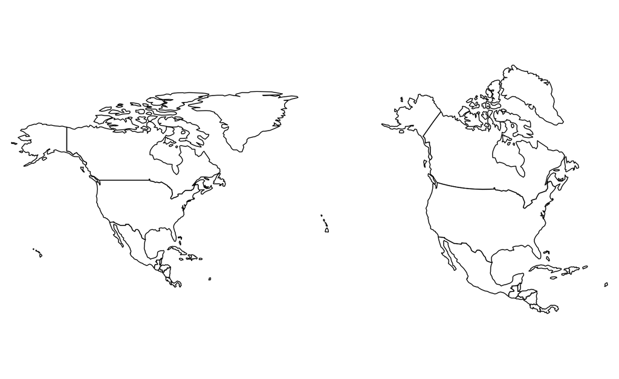

```r
na = world %>%
  filter(continent == "North America")
par(mfrow = c(1, 2), mar=c(0,0,0,0))
plot(na[0]);plot(na_2163[0])
```

## The `world` dataset

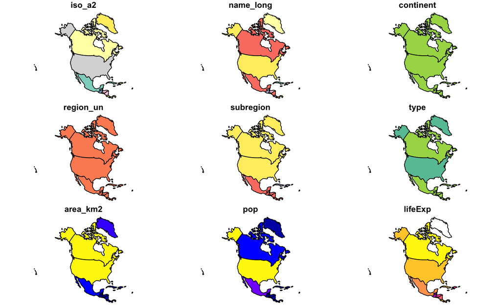

```r
plot(na_2163)
```

## Spatial operations

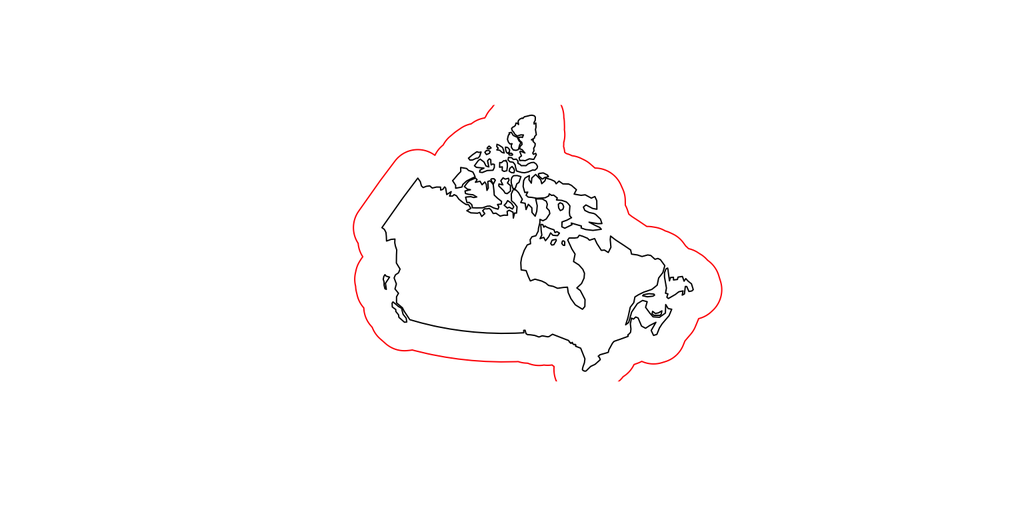

```r
canada = na_2163 %>%
  filter(name_long=="Canada")

canada_buffer=canada%>%
  st_buffer(500000) %>%
  filter()

plot(select(canada,geom))
plot(select(canada_buffer,geom),add=T,border="red")
```

## Basic maps

- Basic maps of `sf` objects can be quickly created using the `plot()` function:

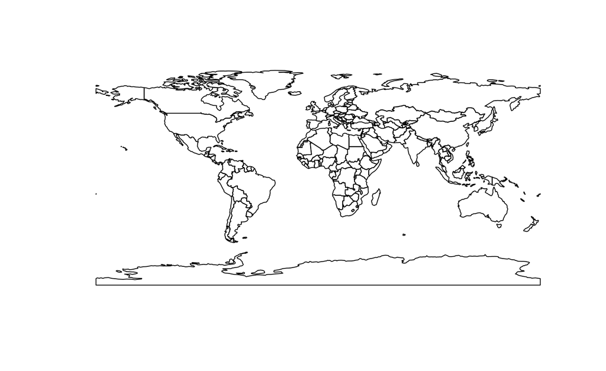

```r
plot(world[0])
```

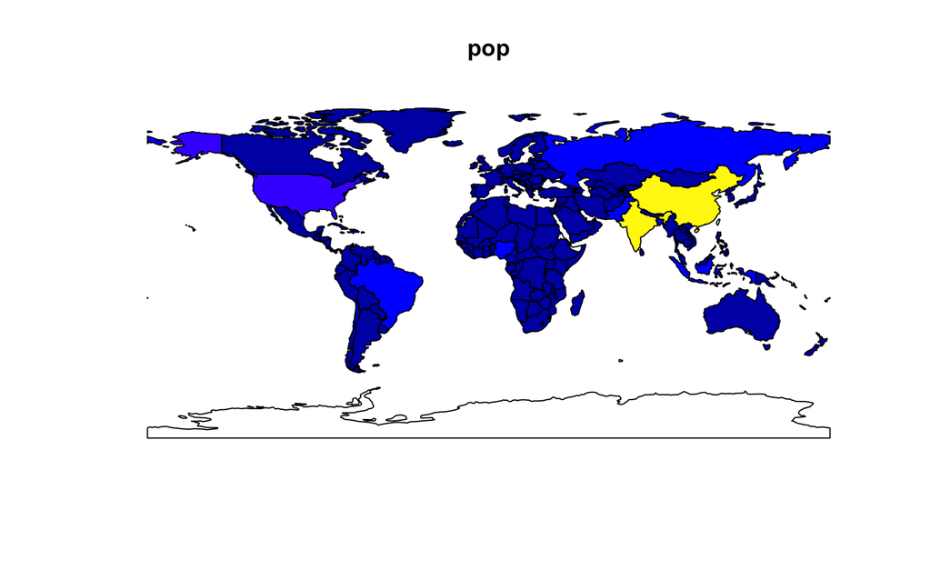

```r
plot(world["pop"])
```

## [tmap](https://cran.r-project.org/web/packages/tmap/vignettes/tmap-nutshell.html): Thematic Maps

Syntax for creating plots is similar to that of ggplot2. The add-on package `tmaptools` contains tool functions for reading and processing shape files.

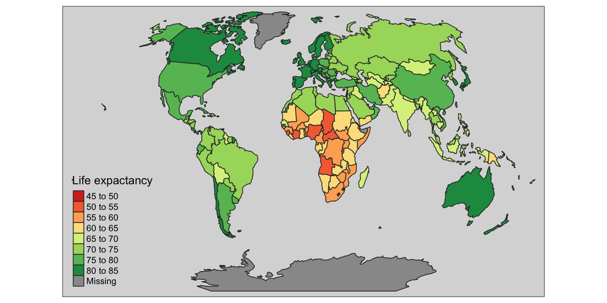

```r
library(tmap)
tmap_mode("plot") #check the "view"
tm_shape(world, projection="wintri") +
        tm_polygons("lifeExp", title=c("Life expactancy"),
          style="pretty", palette="RdYlGn", auto.palette.mapping=FALSE) +
        tm_style_grey()
```

## leaflet

```r
library(leaflet)
library(widgetframe)
leaflet(world) %>%
        addTiles() %>%
        addPolygons(color = "#444444", weight = 1, fillOpacity = 0.5,
                    fillColor = ~colorQuantile("YlOrRd", lifeExp)(lifeExp),
                    popup = paste(round(world$lifeExp, 2)))
```

```r
l = leaflet(world) %>%
  addTiles() %>%
  addPolygons(color = "#444444", weight = 1, fillOpacity = 0.5,
              fillColor = ~colorQuantile("YlOrRd", lifeExp)(lifeExp),
              popup = paste(round(world$lifeExp, 2)))
saveWidget(l, file = "leaflet.html",selfcontained = T)
```

[interactive chart not shown]

## Raster data in the tidyverse

Raster data is not yet closely connected to the **tidyverse**, however:

- Some functions from the **raster** package works well in `pipes`
- You can convert vector data to the `Spatial*` form using `as(my_vector, "Spatial")`before working on raster-vector interactions
- There are some initial efforts to bring raster data closer to the **tidyverse**, such as tabularaster, sfraster, or fasterize
- The development of the stars, package focused on multidimensional, large datasets should start soon. It will allow pipe-based workflows

## Sources

- Slides adapted from:
  - “Robin Lovelace and Jakub Nowosad” draft book [*Geocomputation with R* (to be published in 2018)](http://robinlovelace.net/geocompr/). Source code at https://github.com/robinlovelace/geocompr.
  - [Claudia Engel’s spatial analysis workshop](https://github.com/cengel/rspatial/blob/master/2_spDataTypes.Rmd)